# DTC Final Memo - DRAFT

Ian Basco, Christian Smith, Andy Turner

2023-03-11

#### Link to Tableau Dashboard

https://public.tableau.com/app/profile/ian.ceazar.basco/viz/DataExplorationProject-Suicide/Dashboard1

#### Introduction and Executive Summary

Our team dives into a dataset on global suicides. In this analysis, we conducted an exploratory analysis, and then developed a dashboard. We feel that by using data to investigate suicides, we can help inform actionable insights and spread awareness on the issue of suicide.

We find males of the Boomer and Silent generation between the ages of 35-54 years old to commit the most suicides. Globally, the United States and Russia committed the most suicides between 1985 and 2016. We recommend public health initiatives in these countries to help curb future suicides.

#### Data Set Description:

Our data was sourced from Kaggle, located here: https://www.kaggle.com/datasets/russellyates88/suicide-rates-overview-1985-to-2016?page=2

This is a compiled dataset from the World Health Organization, World Bank, and United Nations members on suicide rates. It contains reported suicide numbers, Human Development Index (HDI), and the Gross Domestic (GDP) reported per country from 1985 to 2016. There are 101 countries represented in the data. The dataset also contains a field for generation (ex: Millennials, Generation X, Generation Z). The data is formatted as a CSV file.

#### Story:

The story we want to get across and communicate is that suicide rates vary by country, the GDPs of each country are associated with suicide rates, and suicide rates vary between each generational group and sex. We want to tell the story that certain countries/demographic groups struggle more with suicide and that by focusing on these demographic groups or countries, we can better understand how to begin addressing the issue of suicide.

#### How We Are Telling the Story and Questions Our Analysis Answers:

To investigate our data and help tell our story, our team developed a dashboard in Tableau. Our team first set up a Github repository, conducted an initial exploratory data analysis in R Studio, and then began developing our Tableau dashboard. The dashboard we developed contains multiple elements:

- A global heat map visual that shows the suicide rate for that country as a certain highlighted color. We incorporated filtering on this chart by calendar year in order to see how the suicide rates for that country change over time.
- A tree-map visualization of suicide rates by generational group that can be filtered by year or country.
- A simple count of suicides by sex (male or female).
- A bar chart visualization of male and female suicides by age group
- And finally, a multi-axis line graph of GDP compared to suicide numbers

There are several interesting questions our dashboard answers:

- Which sex commits suicide more?
- Which age group is most affected by suicide?
- Which generational group is most affected by suicide?
- How do different countries compare in their suicide rates?
- What relationship exists between GDP and suicide rates?

[figure not shown]

#### Results and Our Story Explained:

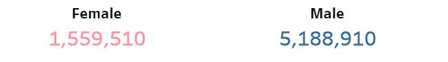

One of the next issues we wanted to examine was which age range is suicide most common? This chart shows the majority of suicides affect those in their ‘middle-age’, typically individuals between the ages of 35-54 years old. Unsurprisingly, we see a ‘bell-curve’ wherein individuals at young and old ages commit suicide less. This visualization is telling of an overriding and alarming result: individuals in the middle of their anticipated lifespans are committing suicide in disproportionate numbers relative to other age groups. There are an infinite number of factors that could play into this, but the result remains the same.

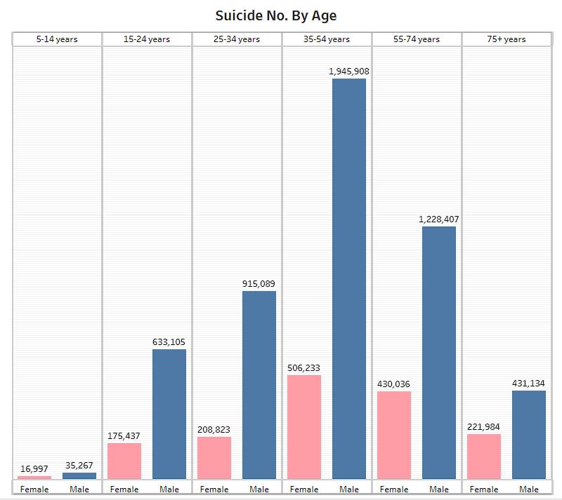

Our team then turns to the issue of answering the question of which generation commits the highest number of suicides. Our treemap shows Boomers and the Silent generation comprised the highest number of suicides in our data set. We saw that individuals in the middle of their anticipated lifespan commit suicide in higher numbers than individuals in other age groups in the previous visualization, and as our data spans 1985-2016, we anticipated seeing Boomers and the Silent generation committing the most suicides as they would have been in their ‘middle’ ages during 1985-2016.

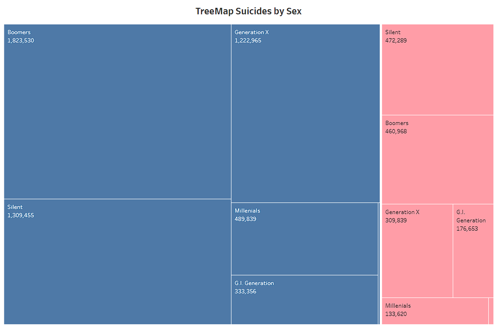

All of our results examined thus far have been on a global level. To examine the intricacies of suicides by country, our team created a global heat map detailing suicides by country. Our heat map clearly shows the United States, Japan, and Russia having the highest number of suicides globally. From an informational perspective, we feel this global heat map allows users to investigate country level suicides and dig further into a specific country.

[figure not shown]

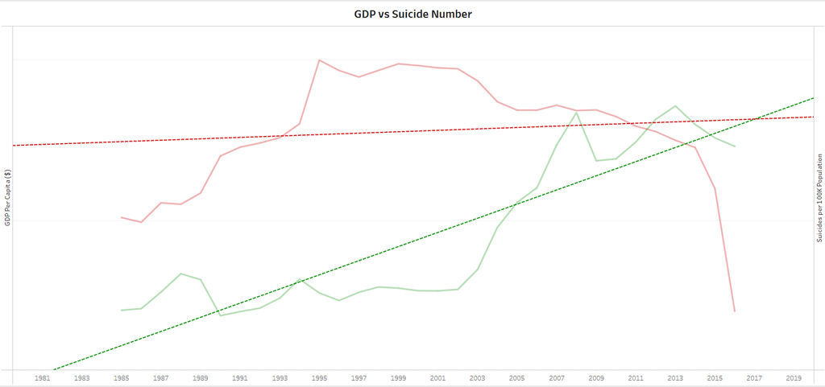

#### Recommendations and Final Thoughts

The issue of suicide is a sobering one. Our analysis has demonstrated that middle-aged males from the Boomer or Silent generation in the United States, Russia, or Japan commit the most suicides. We have found that GDP has increased which suicide rates have remained relatively constant which gives us hope that as time goes on, suicides will continue to remain constant or decline as countries develop and create more advanced economies.

Although our data set is not fully representative of a lot of other information (other countries, data is only for a select number of years), we recommend the following based on our data set and analysis.

- Increase resources and community programs for middle-aged individuals to expand the knowledge and conversation around suicide.
- Encourage and develop further programs and resources for those in the Silent and Boomer generations. Use insights from those conversations and programs to help influence Gen X, Millennials, Gen Z.
- Encourage global leaders to partner with each other to help bring suicide to the forefront of public health conversations.
- Continue monitoring global suicide rates relative to GDP.

We hope this story, dashboard, and analysis has provided a sobering and thought-provoking insight into suicides on a global level. Our team is hopeful for the future and by providing this analysis, we hope to spark further conversation on this heavy topic and encourage those to seek help where needed.